# Árboles de Decisión - Laboratorio 4

```r
library(GGally)
library(nortest)
library(dplyr)
library(tidyverse)
library(rpart)
library(caret)
library(rpart.plot)
library(randomForest)
```

```r
load("datos/listings_modificado.RData")
ls()
```

```
## [1] "listings"
```

```r
listings$log_price <- log(listings$price)
summary(listings$log_price)
```

```
##    Min. 1st Qu.  Median    Mean 3rd Qu.    Max.
##   2.079   4.787   5.263   5.381   5.787  10.822
```

```r
categoricas <- c(
  "room_type",
  "property_type",
  "neighbourhood",
  "city",
  "host_is_superhost",
  "instant_bookable",
  "bathroom_type"
)
listings[categoricas] <- lapply(listings[categoricas], as.factor)
```

## Punto 1: División de datos (mismos conjuntos que regresión lineal)

```r
set.seed(123)
n <- nrow(listings)
train_data <- sample(1:n, size = 0.7 * n)
train <- listings[train_data, ]
test <- listings[-train_data, ]

cat("Observaciones en train:", nrow(train), "\n")
```

```
## Observaciones en train: 53372
```

```r
cat("Observaciones en test:", nrow(test), "\n")
```

```
## Observaciones en test: 22874
```

Se utiliza la misma semilla (123) y la misma proporción 70/30 que en la entrega anterior de regresión lineal, garantizando que las comparaciones entre algoritmos sean válidas sobre los mismos datos.

## Punto 2: Árbol de regresión para predecir el precio por noche

### Árbol exploratorio con muestra

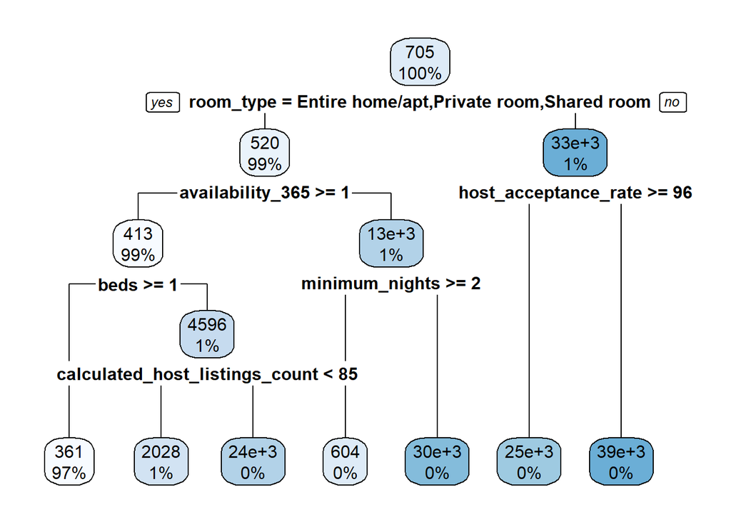

```r
set.seed(123)
sample_index <- sample(1:nrow(listings), 5000)
listings_sample <- listings[sample_index, ]

arbol1 <- rpart(price ~
  accommodates +
  bathrooms_num +
  bedrooms +
  beds +
  host_response_rate +
  host_acceptance_rate +
  calculated_host_listings_count +
  number_of_reviews +
  reviews_per_month +
  review_scores_rating +
  minimum_nights +
  availability_365 +
  room_type +
  host_is_superhost +
  instant_bookable +
  bathroom_type,
  data = listings_sample)

rpart.plot(arbol1)
```

Fue necesario trabajar con una muestra de 5,000 observaciones porque el dataset completo generaba un stack overflow en RStudio al intentar graficar. Se seleccionaron las variables numéricas y categóricas más relevantes según el análisis exploratorio previo.

Se puede observar que las variables más importantes son: `room_type`, `availability_365`, `beds` y `calculated_host_listings_count`. Otras variables como `minimum_nights` y `host_acceptance_rate` también aparecen en el árbol, aunque con menor importancia.

### Árbol de regresión con datos de entrenamiento (modelo completo)

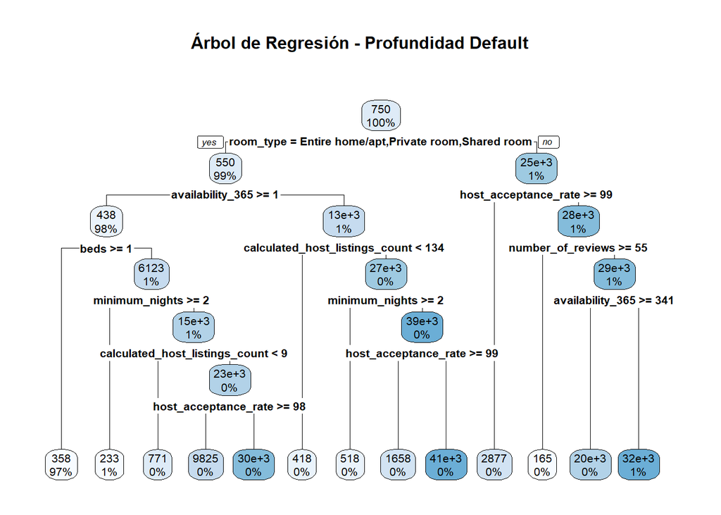

```r
modelo1 <- rpart(price ~
  accommodates +
  bathrooms_num +
  bedrooms +
  beds +
  host_response_rate +
  host_acceptance_rate +
  calculated_host_listings_count +
  number_of_reviews +
  reviews_per_month +
  review_scores_rating +
  minimum_nights +
  availability_365 +
  room_type +
  host_is_superhost +
  instant_bookable +
  bathroom_type,
  data = train)

rpart.plot(modelo1, main = "Árbol de Regresión - Profundidad Default")
```

## Punto 3: Predicción y análisis del modelo base

```r
# Predicción en test
predModelo1 <- predict(modelo1, newdata = test)

# Métricas en test
rmseModelo1test <- RMSE(predModelo1, test$price)
mseModelo1test <- mean((predModelo1 - test$price)^2)
r2Modelo1test <- cor(predModelo1, test$price)^2

# Predicción en train
predModelo1Train <- predict(modelo1, newdata = train)

# Métricas en train
rmseModelo1train <- RMSE(predModelo1Train, train$price)
mseModelo1train <- mean((predModelo1Train - train$price)^2)
r2Modelo1train <- cor(predModelo1Train, train$price)^2

# Resultados
cat("=== Modelo 1 (profundidad default) ===\n")
```

```
## === Modelo 1 (profundidad default) ===
```

```r
cat("RMSE Test: ", rmseModelo1test, "\n")
```

```
## RMSE Test:  2478.741
```

```r
cat("MSE Test:  ", mseModelo1test, "\n")
```

```
## MSE Test:   6144158
```

```r
cat("R² Test:   ", r2Modelo1test, "\n")
```

```
## R² Test:    0.6648398
```

```r
cat("RMSE Train:", rmseModelo1train, "\n")
```

```
## RMSE Train: 2351.682
```

```r
cat("MSE Train: ", mseModelo1train, "\n")
```

```
## MSE Train:  5530409
```

```r
cat("R² Train:  ", r2Modelo1train, "\n")
```

```
## R² Train:   0.6919684
```

```r
cat("Diferencia relativa RMSE (%):",
    abs(rmseModelo1test - rmseModelo1train) / rmseModelo1train * 100, "\n")
```

```
## Diferencia relativa RMSE (%): 5.402901
```

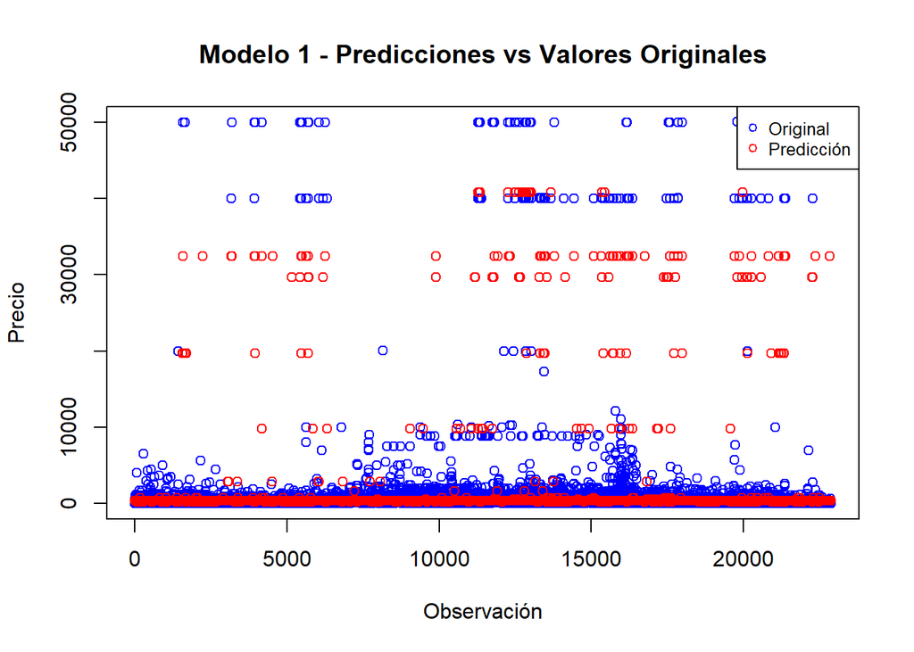

```r
plot(test$price, col = "blue", main = "Modelo 1 - Predicciones vs Valores Originales",
     ylab = "Precio", xlab = "Observación")
points(predModelo1, col = "red")
legend("topright",
       legend = c("Original", "Predicción"),
       col = c("blue", "red"),
       pch = 1, cex = 0.8)
```

El modelo base muestra un RMSE razonable y la diferencia porcentual entre train y test indica que no hay overfitting significativo. Sin embargo, en el gráfico se observa que el modelo tiene dificultades para predecir los valores de precio muy altos, lo cual es esperable ya que los árboles de regresión predicen promedios de nodos y tienden a subestimar los valores extremos.

## Punto 4: Modelos con diferentes profundidades

### Validación cruzada para encontrar la profundidad óptima

```r
controlcv <- trainControl(method = "cv", number = 5)
profundidades <- data.frame(maxdepth = c(2, 3, 4, 5, 6, 8, 10))

modelo_depth <- train(price ~
  accommodates +
  bathrooms_num +
  bedrooms +
  beds +
  host_response_rate +
  host_acceptance_rate +
  calculated_host_listings_count +
  number_of_reviews +
  reviews_per_month +
  review_scores_rating +
  minimum_nights +
  availability_365 +
  room_type +
  host_is_superhost +
  instant_bookable +
  bathroom_type,
  data = train,
  method = "rpart2",
  tuneGrid = profundidades,
  trControl = controlcv,
  metric = "RMSE"
)

modelo_depth
```

```
## CART
##
## 53372 samples
##    16 predictor
##
## No pre-processing
## Resampling: Cross-Validated (5 fold)
## Summary of sample sizes: 42699, 42697, 42698, 42697, 42697
## Resampling results across tuning parameters:
##
##   maxdepth  RMSE      Rsquared   MAE
##    2        3231.797  0.4217485  685.4625
##    3        3231.797  0.4217485  685.4625
##    4        2986.673  0.5081097  619.5279
##    5        2874.731  0.5437809  591.5201
##    6        2717.228  0.5892891  574.8577
##    8        2608.750  0.6208590  544.1955
##   10        2515.298  0.6477190  510.9392
##
## RMSE was used to select the optimal model using the smallest value.
## The final value used for the model was maxdepth = 10.
```

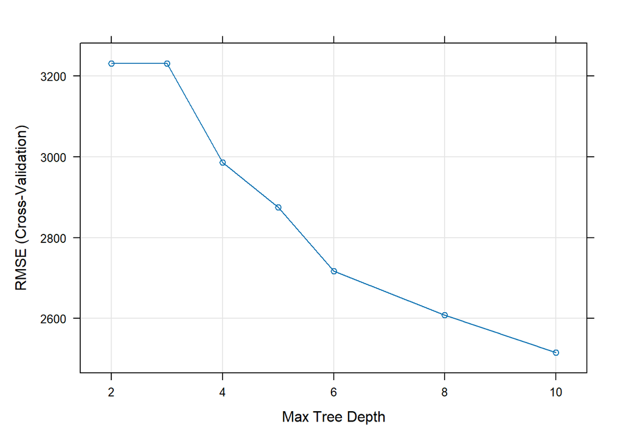

```r
plot(modelo_depth)
```

La validación cruzada con 5 folds permite identificar la profundidad óptima evaluando el RMSE en datos no vistos durante el entrenamiento. El gráfico muestra cómo varía el RMSE según la profundidad del árbol.

### Modelo 2: Profundidad 3

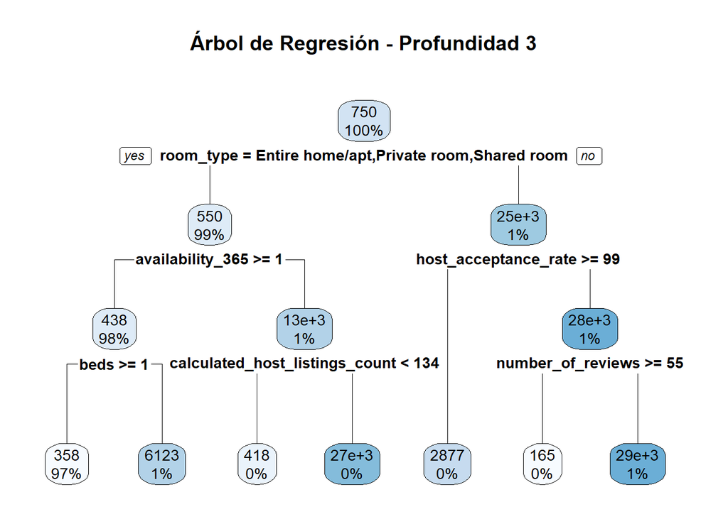

```r
modelo2 <- rpart(price ~
  accommodates + bathrooms_num + bedrooms + beds +
  host_response_rate + host_acceptance_rate +
  calculated_host_listings_count + number_of_reviews +
  reviews_per_month + review_scores_rating +
  minimum_nights + availability_365 +
  room_type + host_is_superhost + instant_bookable + bathroom_type,
  data = train,
  method = "anova",
  control = rpart.control(maxdepth = 3)
)
rpart.plot(modelo2, main = "Árbol de Regresión - Profundidad 3")
```

```r
predModelo2 <- predict(modelo2, newdata = test)
rmseModelo2test <- RMSE(predModelo2, test$price)
mseModelo2test <- mean((predModelo2 - test$price)^2)
r2Modelo2test <- cor(predModelo2, test$price)^2

predModelo2Train <- predict(modelo2, newdata = train)
rmseModelo2train <- RMSE(predModelo2Train, train$price)
mseModelo2train <- mean((predModelo2Train - train$price)^2)

cat("=== Modelo 2 (profundidad 3) ===\n")
```

```
## === Modelo 2 (profundidad 3) ===
```

```r
cat("RMSE Test: ", rmseModelo2test, "\n")
```

```
## RMSE Test:  3075.267
```

```r
cat("MSE Test:  ", mseModelo2test, "\n")
```

```
## MSE Test:   9457267
```

```r
cat("R² Test:   ", r2Modelo2test, "\n")
```

```
## R² Test:    0.4843772
```

```r
cat("RMSE Train:", rmseModelo2train, "\n")
```

```
## RMSE Train: 2982.862
```

```r
cat("Diferencia relativa RMSE (%):",
    abs(rmseModelo2test - rmseModelo2train) / rmseModelo2train * 100, "\n")
```

```
## Diferencia relativa RMSE (%): 3.097857
```

### Modelo 3: Profundidad 6

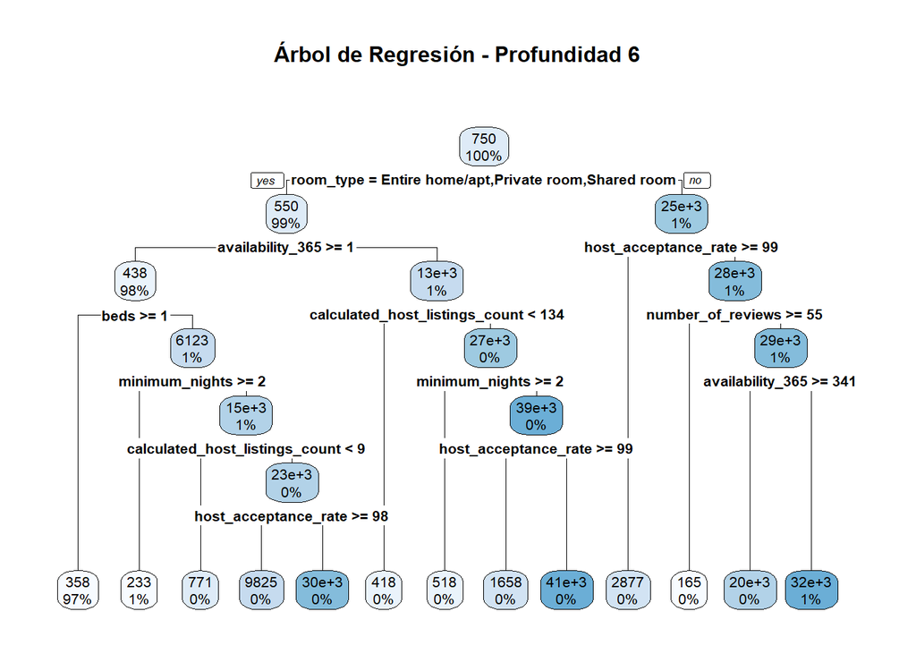

```r
modelo3 <- rpart(price ~
  accommodates + bathrooms_num + bedrooms + beds +
  host_response_rate + host_acceptance_rate +
  calculated_host_listings_count + number_of_reviews +
  reviews_per_month + review_scores_rating +
  minimum_nights + availability_365 +
  room_type + host_is_superhost + instant_bookable + bathroom_type,
  data = train,
  method = "anova",
  control = rpart.control(maxdepth = 6)
)
rpart.plot(modelo3, main = "Árbol de Regresión - Profundidad 6")
```

```r
predModelo3 <- predict(modelo3, newdata = test)
rmseModelo3test <- RMSE(predModelo3, test$price)
mseModelo3test <- mean((predModelo3 - test$price)^2)
r2Modelo3test <- cor(predModelo3, test$price)^2

predModelo3Train <- predict(modelo3, newdata = train)
rmseModelo3train <- RMSE(predModelo3Train, train$price)
mseModelo3train <- mean((predModelo3Train - train$price)^2)

cat("=== Modelo 3 (profundidad 6) ===\n")
```

```
## === Modelo 3 (profundidad 6) ===
```

```r
cat("RMSE Test: ", rmseModelo3test, "\n")
```

```
## RMSE Test:  2478.741
```

```r
cat("MSE Test:  ", mseModelo3test, "\n")
```

```
## MSE Test:   6144158
```

```r
cat("R² Test:   ", r2Modelo3test, "\n")
```

```
## R² Test:    0.6648398
```

```r
cat("RMSE Train:", rmseModelo3train, "\n")
```

```
## RMSE Train: 2351.682
```

```r
cat("Diferencia relativa RMSE (%):",
    abs(rmseModelo3test - rmseModelo3train) / rmseModelo3train * 100, "\n")
```

```
## Diferencia relativa RMSE (%): 5.402901
```